# Ordinal Logistic Regression

## How to use `Polr()`

The basic structure of the function looks like this:

`polr(formula, data, weights, start, ..., subset, na.action, contrasts = NULL, Hess = FALSE, model = TRUE, method = c("logistic", "probit", "loglog", "cloglog", "cauchit"))`

Here,

- `formula` a formula expression as for regression models, of the form response ~ predictors. The response should be a factor (preferably an ordered factor), which will be interpreted as an ordinal response, with levels ordered as in the factor. The model must have an intercept: attempts to remove one will lead to a warning and be ignored. An offset may be used. See the documentation of formula for other details.
- `data` an optional data frame, list or environment in which to interpret the variables occurring in formula.
- `weights` optional case weights in fitting. Default to 1.
- `start` initial values for the parameters. This is in the format c(coefficients, zeta): see the Values section.
- `...` additional arguments to be passed to optim, most often a control argument.
- `subset` expression saying which subset of the rows of the data should be used in the fit. All observations are included by default.
- `na.action` a function to filter missing data.
- `contrasts` a list of contrasts to be used for some or all of the factors appearing as variables in the model formula.
- `Hess` logical for whether the Hessian (the observed information matrix) should be returned. Use this if you intend to call summary or variance covariance on the fit.
- `model` logical for whether the model matrix should be returned.
- `method` logistic or probit or (complementary) log-log or cauchit (corresponding to a Cauchy latent variable).

## Fitting the model

Using this function lets fit the data,

```r
## fitting the model

fit_olr_mod <-
  MASS::polr(y ~ ., data = df, Hess = T)

pander(summary(fit_olr_mod))
```

Call: MASS::polr(formula = y ~ ., data = df, Hess = T)

Coeficients

|  | Value | Std. Error | t value |
| --- | --- | --- | --- |
| **sexMale** | 0.1513 | 0.1377 | 1.099 |
| **age** | -0.01366 | 0.005713 | -2.391 |
| **treatmentDrug** | 0.5454 | 0.1255 | 4.347 |
| **baseline2** | 0.6288 | 0.2708 | 2.322 |
| **baseline3** | 1.152 | 0.2591 | 4.446 |
| **baseline4** | 2.474 | 0.2931 | 8.442 |
| **baseline5** | 3.994 | 0.426 | 9.376 |

Intercepts

|  | Value | Std. Error | t value |
| --- | --- | --- | --- |
| **1\|2** | -2.595 | 0.4306 | -6.026 |
| **2\|3** | -0.5127 | 0.4092 | -1.253 |
| **3\|4** | 1.442 | 0.4139 | 3.485 |
| **4\|5** | 3.744 | 0.4298 | 8.711 |

Residual Deviance: 2238.92

AIC: 2260.92

The function gives us the coefficients, intercepts along with their standard error and t statistic.

## Odds Ratio

In order to get the Odds Ratio and their confidence interval we take the exponential of the coefficient. There is no straight forward way of doing that in `R`. Below is one way of solving that issue.

```r
## Odds ratio and Confidence Interval

CI <- confint(fit_olr_mod)
Waiting for profiling to be done...
results <- data.frame(
  Variable = c(
    "sex_male", "age", "treatment_drug", "baseline_2", "baseline_3", "baseline_4",
    "baseline_5"
  ),
  OR = exp(fit_olr_mod$coefficients),
  lower = exp(CI[, 1]),
  upper = exp(CI[, 2])
)
odds_ratio <- results %>% tibble()
pander(odds_ratio)
```

| Variable | OR | lower | upper |
| --- | --- | --- | --- |
| sex_male | 1.163 | 0.8883 | 1.524 |
| age | 0.9864 | 0.9754 | 0.9975 |
| treatment_drug | 1.725 | 1.35 | 2.208 |
| baseline_2 | 1.875 | 1.103 | 3.193 |
| baseline_3 | 3.164 | 1.906 | 5.268 |
| baseline_4 | 11.87 | 6.701 | 21.16 |
| baseline_5 | 54.25 | 23.71 | 126.3 |

## Interpreting the Results

- *Sex:* Compared to female participants, Male participants had 1.16 fold higher odds of reporting high score of rheumatoid arthritis
- *Age:* For 1 year change in age the odds of reporting high rheumatoid arthritis score changes 0.99 times.
- *Treatment:* Compared to the Placebo group participants, the participant who received the drug had 1.73 times higher odds of reporting high score of rheumatoid arthritis.

## Checking Assumptions

Next we check the key assumptions to verify whether the model is appropriate to use.

### Multicollinearity

#### Pairs Plot

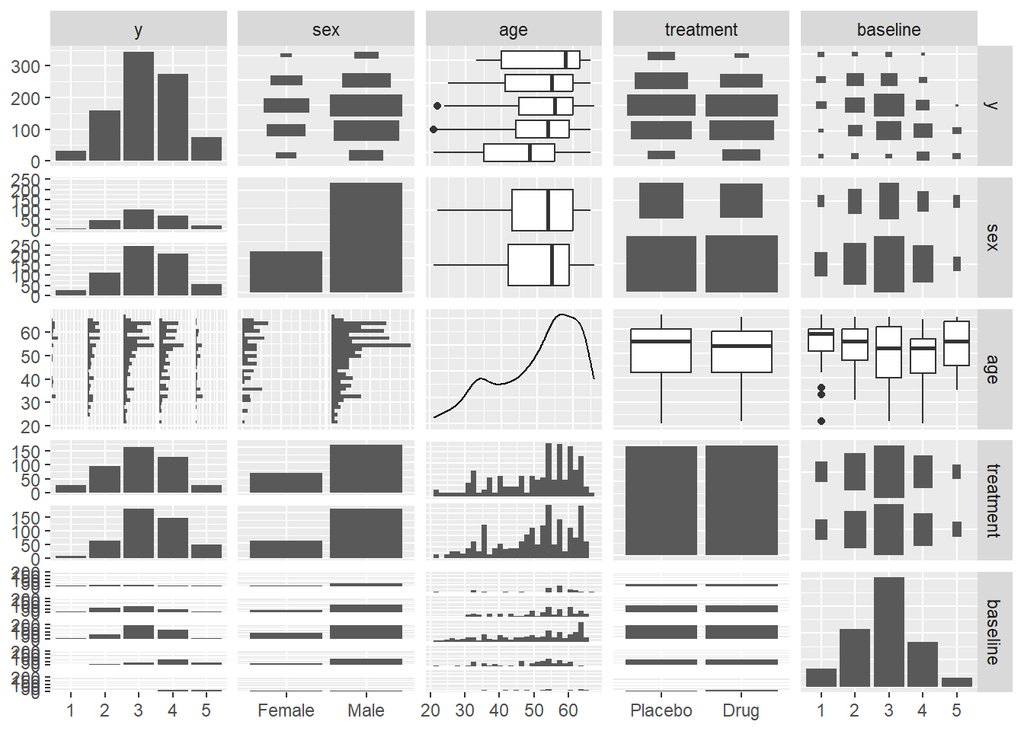

```r
## model assumption

# Pairs plot to check multicollinearity
df %>%
  GGally::ggpairs()
Registered S3 method overwritten by 'GGally':
  method from
  +.gg   ggplot2
`stat_bin()` using `bins = 30`. Pick better value with `binwidth`.
`stat_bin()` using `bins = 30`. Pick better value with `binwidth`.
`stat_bin()` using `bins = 30`. Pick better value with `binwidth`.
`stat_bin()` using `bins = 30`. Pick better value with `binwidth`.
```

As there is only have one continuous variable the `pairs` plot is not that useful. So instead let’s check the pairwise correlation among predictors.

#### Correlation Plot

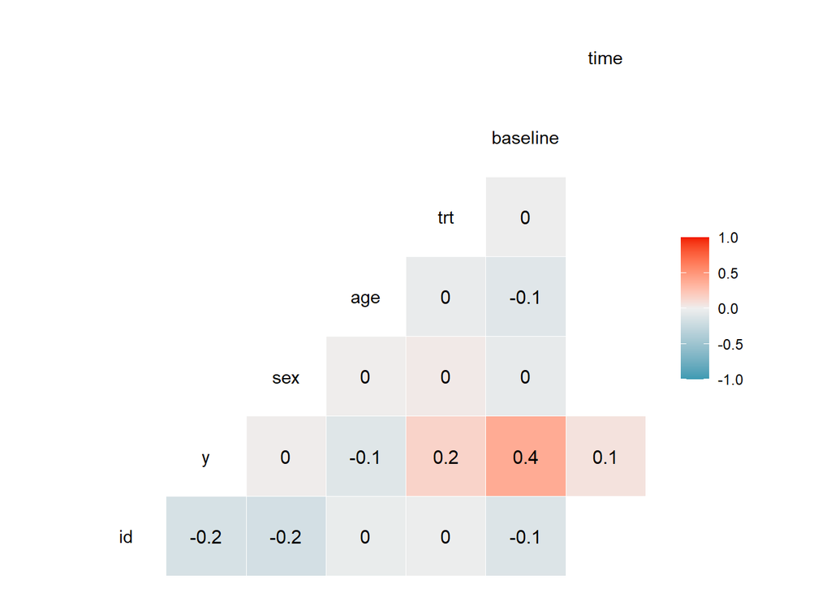

```r
arthritis_df %>%
  GGally::ggcorr(
    method = c("pairwise"),
    label = TRUE
  ) # low cor coft, may assume no multicollinearity
```

The correlation is quite low among the predictors so there is no multicollinearity.

### Proportional Odds

Ordinal logistic regression makes the assumption that the relationship between each pair of outcome groups is the same. In other words, ordinal logistic regression assumes that the coefficients describing the relationship between, say, the lowest and all higher categories of the response variable are the same as those describing the relationship between the next lowest and all higher categories, and so on. This assumption can be vefied several way. Here, I have used a package called (Wong 2021) that generates graphics to check for proportional odds assumption created by UCLA statistical consulting group [see more](https://stats.oarc.ucla.edu/) .

#### Graphics to check for proportional odds

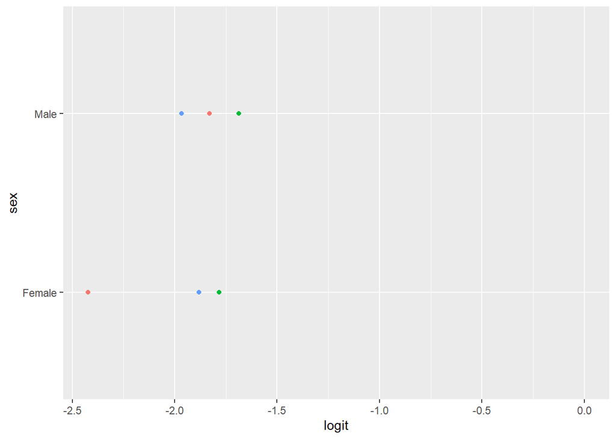

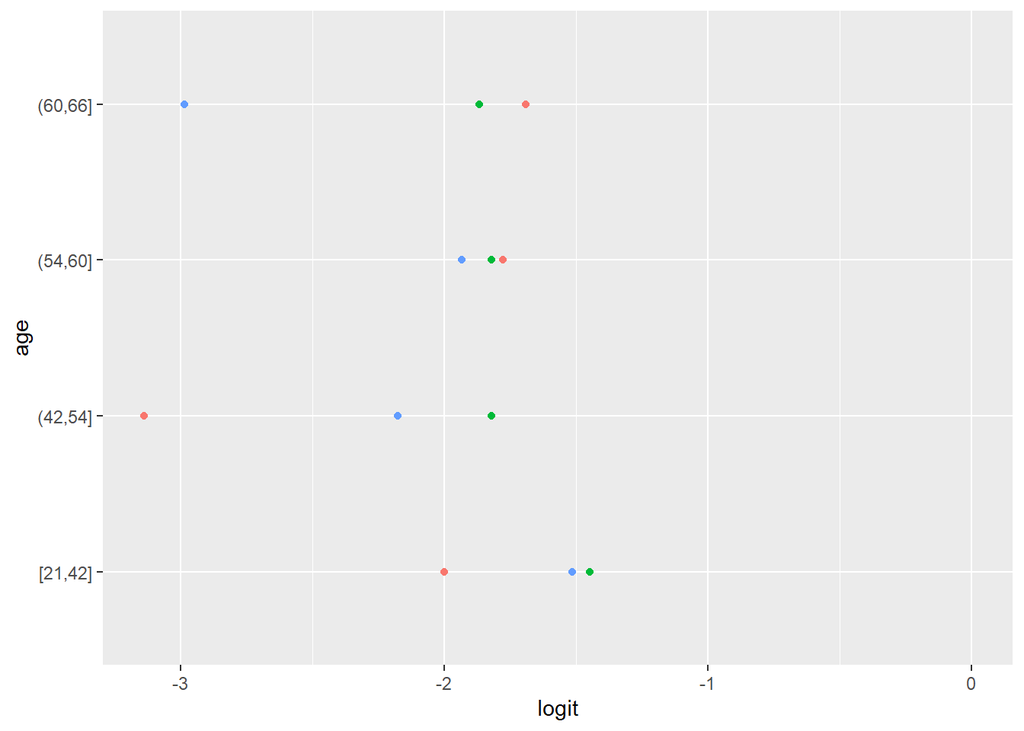

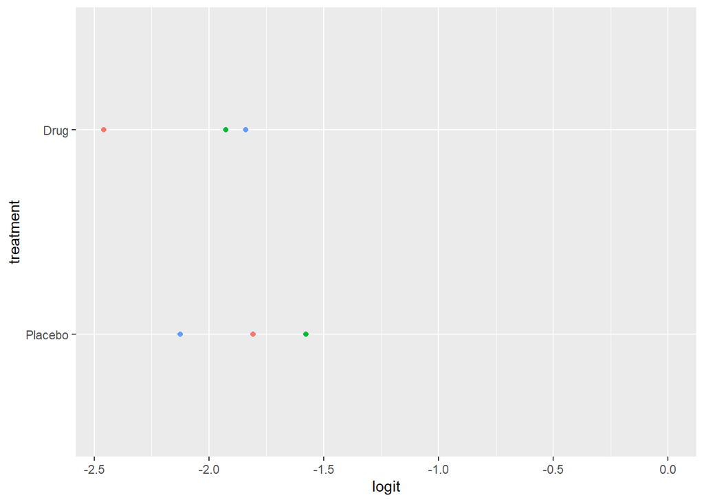

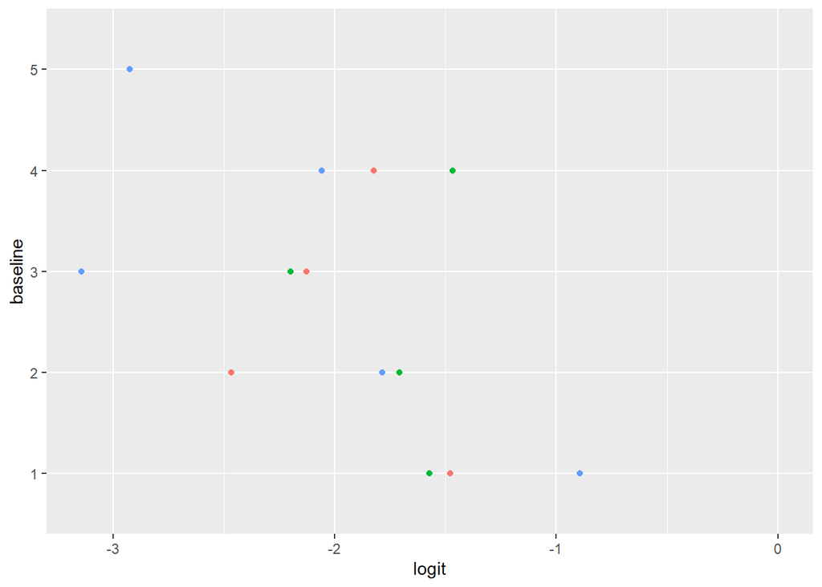

```r
# install.packages("pomcheckr")
library(pomcheckr)
pomchk <-
  pomcheck(y ~ sex + age + treatment + baseline, data = df)
plot(pomchk)
```

Here the function is calculating the difference in proportion of the categories in the outcome variable and plotting them against each category of the predictors. In idea case scinario is the distance between the dots in each line is somewhat equal they will be considered proportional.

## References

Agresti, Alan. 2002. “Categorical Data Analysis.” *Wiley Series in Probability and Statistics*, July. https://doi.org/10.1002/0471249688.

Wong, Melissa. 2021. “Pomcheckr: Graphical Check for Proportional Odds Assumption.” https://CRAN.R-project.org/package=pomcheckr.